# Homework 2 Solutions

# Exercise 7.5.3.1

1. Instead of summarising the conditional distribution with a boxplot, you could use a frequency polygon. What do you need to consider when using cut_width() vs cut_number()? How does that impact a visualisation of the 2d distribution of carat and price?

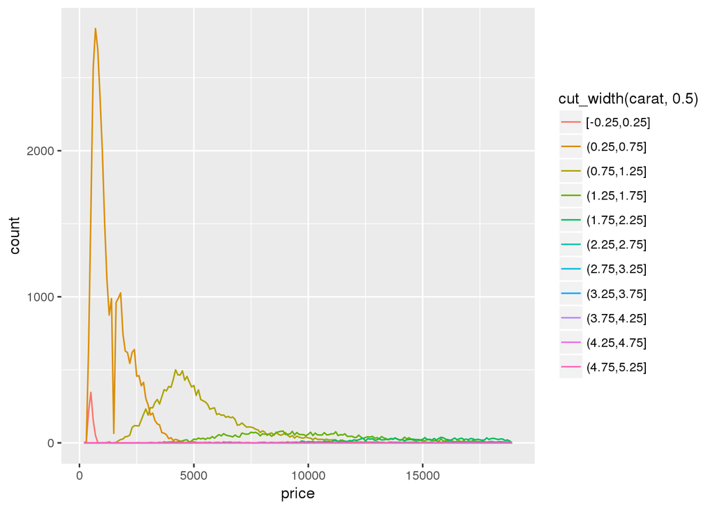

   ```r
   ggplot(data = diamonds, aes(x = price, color = cut_width(carat, 0.5))) +
     geom_freqpoly(binwidth = 100)
   ```

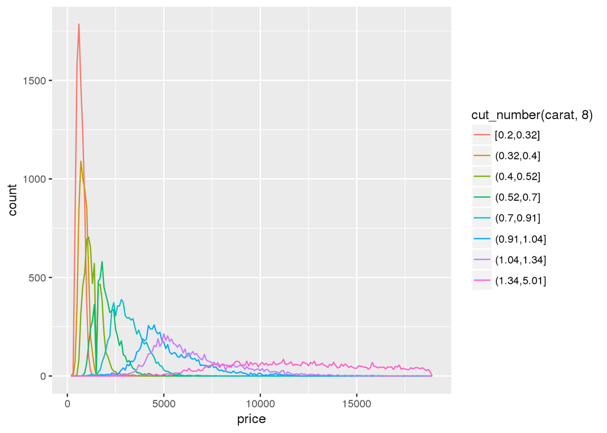

   ```r
   ggplot(data = diamonds, aes(x = price, color = cut_number(carat, 8))) +
     geom_freqpoly(binwidth = 100)
   ```

   Answer: as the code shown above, both cut_width() and cut_number() subset a continuous variable into different interval groups. The only difference is that for cut_width() we only need to specify how big each interval shall be while for cut_number() we need to specify how many intervals we want. It really comes down to the structure of the data and our preference. If one needs to divide data into a specific number carat (or weight, or length, any continuous variable) groups then they should use cut_number(), and use cut_width() otherwise. Personally I would try using cut_number() first on a data that I’m not familiar with (especially when I don’t know the range of the variable) in case it’s cut into too many groups.
2. Visualise the distribution of carat, partitioned by price.

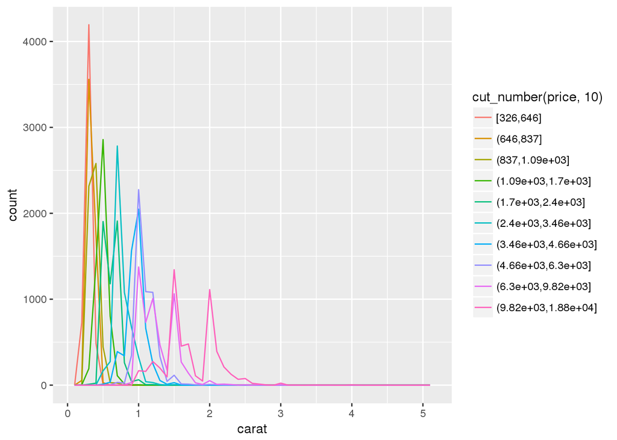

   ```r
   ggplot(data = diamonds, aes(x = carat, color = cut_number(price, 10))) +
     geom_freqpoly(binwidth = 0.1)
   ```

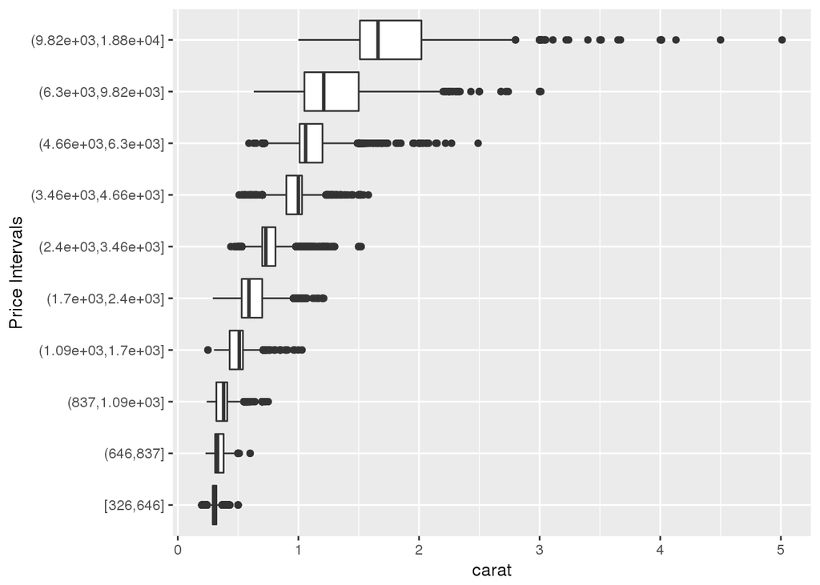

   ```r
   ggplot(data = diamonds, aes(x = cut_number(price, 10), y = carat)) +
     geom_boxplot() +
     coord_flip() +
     labs(x = "Price Intervals")
   ```

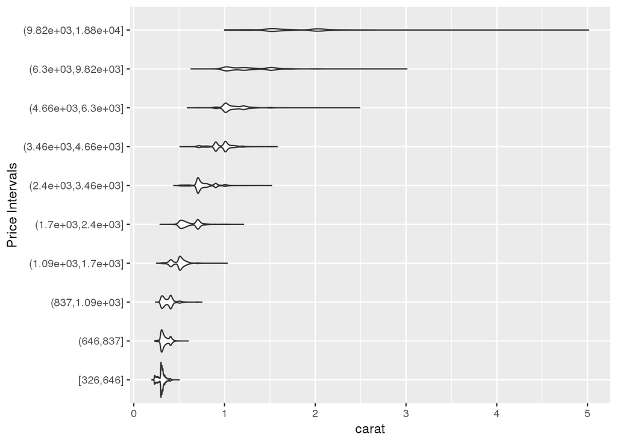

   ```r
   ggplot(data = diamonds, aes(x = cut_number(price, 10), y = carat)) +
     geom_violin() +
     coord_flip() +
     labs(x = "Price Intervals")
   ```

   Answer: I plotted a frequency polygon, a boxplot, and a violin, for a comprehensive view of their distributions.
3. How does the price distribution of very large diamonds compare to small diamonds. Is it as you expect, or does it surprise you?

   Answer: from the plots above (especially the boxplot), we can tell that there might be a trend of higher-priced diamonds having greater carat values. However, we also see greater variations among higher-priced diamonds. We see more, and farther outliers in higher price diamonds as well. I would say it’s as expected, since the higher the price, the more factors come in, such as its cut, clarity, and other properties, not just carat. You can have a big piece of (big carat) diamond, with low quality, compared to another with both good size and quality, and they will have a big difference in price.
4. Combine two of the techniques you’ve learned to visualise the combined distribution of cut, carat, and price.

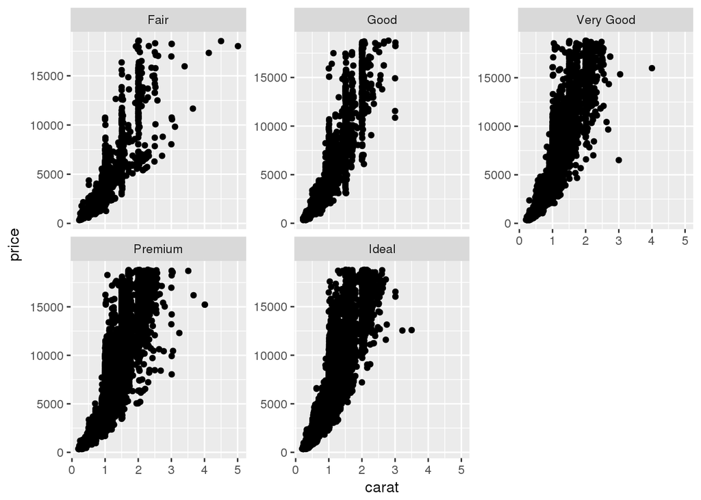

   ```r
   ggplot(data = diamonds, aes(x = carat, y = price)) +
     geom_point() +
     facet_wrap(~cut, scales = "free_y")
   ```

   Answer: because in this case, we care about the relationship between the two variables. As we can see x and y are closely related. A binned plot (such as histogram) will not review the “relationship outliers”, that is, values that aren’t extreme for x or y alone but can be considered outliers when one looks at their relationship.

## Q3

Redo HW1 Q2 using tidyverse.

1. How many persons are in the data set (statisticians call this n)? How many SNPs are in the data set (statisticians call this p)?

   ```r
   library(tidyverse)
   setwd("/home/m280-data/hw1")
   geno_bim <- read_delim("merge-geno.bim", col_names = FALSE, delim = "\t")
   geno_fam <- read_delim("merge-geno.fam", col_names = FALSE, delim = " ")
   geno_fam %>%
     filter(!is.na(geno_fam[, 2])) %>%
     summarise(Number_of_Persons = n_distinct(geno_fam[, 2]))
   ```

   ```
   ## # A tibble: 1 x 1
   ##   Number_of_Persons
   ##               <int>
   ## 1               959
   ```

   ```r
   geno_bim %>%
     filter(!is.na(geno_bim[, 2])) %>%
     summarise(Number_of_SNPs = n_distinct(geno_bim[, 2]))
   ```

   ```
   ## # A tibble: 1 x 1
   ##   Number_of_SNPs
   ##            <int>
   ## 1        8348674
   ```

   Answer: the results are printed above
2. Which chromosomes does this data set contain? How many SNPs are in each chromosome?

   ```r
   geno_bim %>%
     filter(!is.na(X2), !is.na(X1)) %>%
     group_by(X1) %>%
     summarise(X2 = n_distinct(X2)) %>%
     arrange(X1)
   ```

   ```
   ## # A tibble: 11 x 2
   ##       X1      X2
   ##    <int>   <int>
   ##  1     1 1309299
   ##  2     3 1215399
   ##  3     5 1090185
   ##  4     7  980944
   ##  5     9  732013
   ##  6    11  815860
   ##  7    13  602809
   ##  8    15  491208
   ##  9    17  477990
   ## 10    19  393615
   ## 11    21  239352
   ```

   Answer: the results have been sorted and printed above. Note that “X1” is chromosome and “X2” is the number of SNP’s
3. MAP4 (microtubule-associated protein 4) is a gene on chromosome 3 spanning positions 47,892,180 bp – 48,130,769 bp. How many SNPs are located within MAP4 gene?

   ```r
   geno_bim %>%
     filter(!is.na(X4), X4 >= 47892180, X4 <= 48130769) %>%
     summarise(Number_of_MAP4 = n())
   ```

   ```
   ## # A tibble: 1 x 1
   ##   Number_of_MAP4
   ##            <int>
   ## 1          12423
   ```

   ```r
   header <- c("     2.40 = FILE FORMAT VERSION NUMBER.\n",
               " 8348674  = NUMBER OF SNPS LISTED HERE.")
   writeLines(header, "Mendel.bim")

   geno_bim %>%
     select(X2, X1, X4) %>%
     write.table(file = "Mendel.bim", sep = ",", quote = FALSE,
                 row.names = FALSE, col.names = FALSE, append = TRUE)


   geno_fam %>%
     mutate(X2 = str_sub(X2, 5, 11), X3 = str_sub(X3, 5, 11),
            X4 = str_sub(X4, 5, 11),
            X5 = ifelse(X5 == 1, "M", "F"), X7 = "") %>%
     select(X1, X2, X3, X4, X5, X7) %>%
     write.table(file = "Mendel.fam",
                 sep = ",", quote = FALSE,
                 row.names = FALSE, col.names = FALSE)
   ```

   Answer: R code above has successfully written data in correct format to files “Mendel.bim” and “Mendel.fam” in the working directory.

   ```bash
   head Mendel.bim
   ```

   ```
   ##      2.40 = FILE FORMAT VERSION NUMBER.
   ##
   ##  8348674  = NUMBER OF SNPS LISTED HERE.
   ## 1-54490,1,54490
   ## 1-55550,1,55550
   ## 1-57033,1,57033
   ## 1-57064,1,57064
   ## 1-57818,1,57818
   ## 1-58432,1,58432
   ## 1-58448,1,58448
   ```

   Above is the head of reformatted bim file

   ```bash
   head Mendel.fam
   ```

   ```
   ## 2,0200001,,,M,
   ## 2,0200002,,,F,
   ## 2,0200003,,,F,
   ## 2,0200004,,,F,
   ## 2,0200005,,,M,
   ## 2,0200006,,,M,
   ## 2,0200007,,,F,
   ## 2,0200008,,,F,
   ## 2,0200009,,,F,
   ## 2,0200012,,,M,
   ```

   Above is the head of reformatted fam file